# Model Selection for Regression

04/04/2018

## Variable Selection

- We have discussed what linear regression is and how to check the assumptions and evaluate the model we have.
- A key issue remains still and that is how do we appropriately build a good model for the data?
- How do we select the variables that we wish to include in this "good" model?

## All Subsets Regression

- There are a number of methods for choosing variable selection.
- Let us consider systolic blood pressure again.
- This time we will brainstorm what all might predict a persons systolic blood pressure

## Why These Variables?

- These may not be all the predictors but they will provide us with a wealth of models in order to best fit systolic blood pressure.
- We will begin first with a concept called all possible subsets.
- With this we consider all \(m\) variables in the full model and all \(2^m\) possible subsets. We will show how to use this in R.

## Leaps Package

```r
###################
##     RUN THIS IN R FOR CLASS    ##
###################

 library(leaps)
 leaps <- regsubsets(sysbp1t~ bmi1 + age1 +
                       diabp1 + prevhyp1 + prevchd1 + prevmi1 +
 cursmoke1 + cigpday1 + bpmeds1, data=fhs, nbest=1)

summary(leaps)
```

## What is This Code?

- The code for this is there, we call up the `leaps` package and then from this use the `regsubsets()` function.
- We place the full model into the command followed by what my dataset is.
- Finally we ask it to display the number of best subsets.

## What does this do?

- Essentially if we choose `nbest=1` we are asking for the top subset for each of possible subsets of size 1 up to 8.
- we could view the top 2, 3 or more if we change this.
- Finally the `summary()` function gives us the results of what we have.
- Running this code gives us

## Leaps Package

```r
 library(leaps)
 leaps <- regsubsets(sysbp1t~ bmi1 + age1 +
                       diabp1 + prevhyp1 + prevchd1 + prevmi1 +
 cursmoke1 + cigpday1 + bpmeds1, data=fhs, nbest=1)
```

## Summary of Leaps

```r
library(dplyr)
summ <- summary(leaps)
knitr::kable(as_data_frame(summ$which))
```

## Summary of Leaps

| bmi1 | age1 | diabp1 | prevhyp1Yes | prevchd1Yes | prevmi1Yes | cursmoke1Yes | cigpday1 | bpmeds1Yes |
| --- | --- | --- | --- | --- | --- | --- | --- | --- |
| FALSE | FALSE | TRUE | FALSE | FALSE | FALSE | FALSE | FALSE | FALSE |
| FALSE | FALSE | TRUE | TRUE | FALSE | FALSE | FALSE | FALSE | FALSE |
| FALSE | TRUE | TRUE | TRUE | FALSE | FALSE | FALSE | FALSE | FALSE |
| FALSE | TRUE | TRUE | TRUE | FALSE | FALSE | FALSE | FALSE | TRUE |
| TRUE | TRUE | TRUE | TRUE | FALSE | FALSE | FALSE | FALSE | TRUE |
| TRUE | TRUE | TRUE | TRUE | FALSE | FALSE | FALSE | TRUE | TRUE |
| TRUE | TRUE | TRUE | TRUE | FALSE | FALSE | TRUE | TRUE | TRUE |
| TRUE | TRUE | TRUE | TRUE | FALSE | TRUE | TRUE | TRUE | TRUE |

## What do We see?

- We can then see what variables would be in the best model subset from a subset of size 1 up to 8.
- A quick look into this function and we find that we can also find out a number of other pieces of information.

## What Else does Leaps give?

```r
names(summ)
```

```
## [1] "which"  "rsq"    "rss"    "adjr2"  "cp"     "bic"    "outmat" "obj"
```

## Useful Information

We can then see that

- *summ$adjr2* would give us a vector with the \(R^2_{adj}\) value for each of the 8 models.
- *summ$bic* would give us a vector with all of the BIC for each of the 8 models.

## Using \(R^2_{adj}\)

- We could then use these to create a table of values we care about for model selection.
- We could also graph \(R^2_{adj}\):

## Using \(R^2_{adj}\)

```r
library(car)
layout(matrix(1:2, ncol = 2))
# Adjusted R2
res.legend <- subsets(leaps, statistic="adjr2", legend = FALSE, min.size = 3,
main = "Adjusted R^2")
# Mallow Cp
res.legend <- subsets(leaps, statistic="cp", legend = FALSE, min.size = 3,
main = "Mallow Cp")
abline(a = 1, b = 1, lty = 2)
```

[output not shown]

## Using \(R^2_{adj}\)

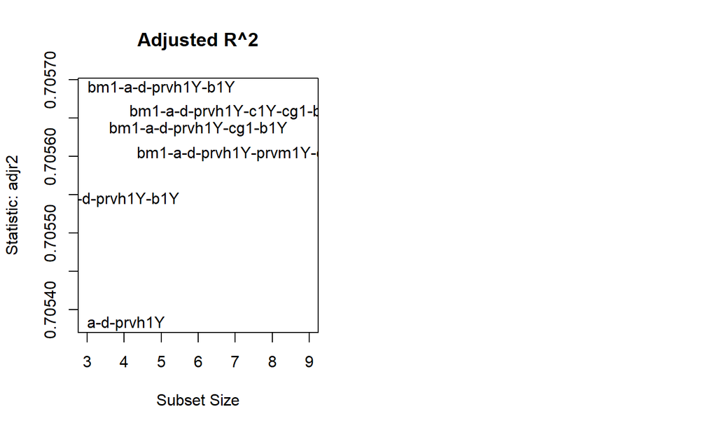

## Using \(R^2_{adj}\)

- We would then have the following legend for these plots

```r
res.legend
```

```
##              Abbreviation
## bmi1                  bm1
## age1                    a
## diabp1                  d
## prevhyp1Yes        prvh1Y
## prevchd1Yes        prvc1Y
## prevmi1Yes         prvm1Y
## cursmoke1Yes          c1Y
## cigpday1              cg1
## bpmeds1Yes            b1Y
```

## What does this tell us?

- We can see from the figure that the model with the 5 predictors has the highest \(R^2_{adj}\). This is the model \[sysbp1t = \beta_0 + \beta_1 bmi1 + \beta_2 age1 + \beta_3 diabp1 + \beta_4 prevhyp1 + \beta_5 bpmeds1 \]

## \(R^2_{adj}\) Plot

- Finally we could create one more plot with \(R^2_{adj}\)

```r
plot(leaps, scale="adjr2", main="")
```

## \(R^2_{adj}\) Plot

- Finally we could create one more plot with \(R^2_{adj}\)

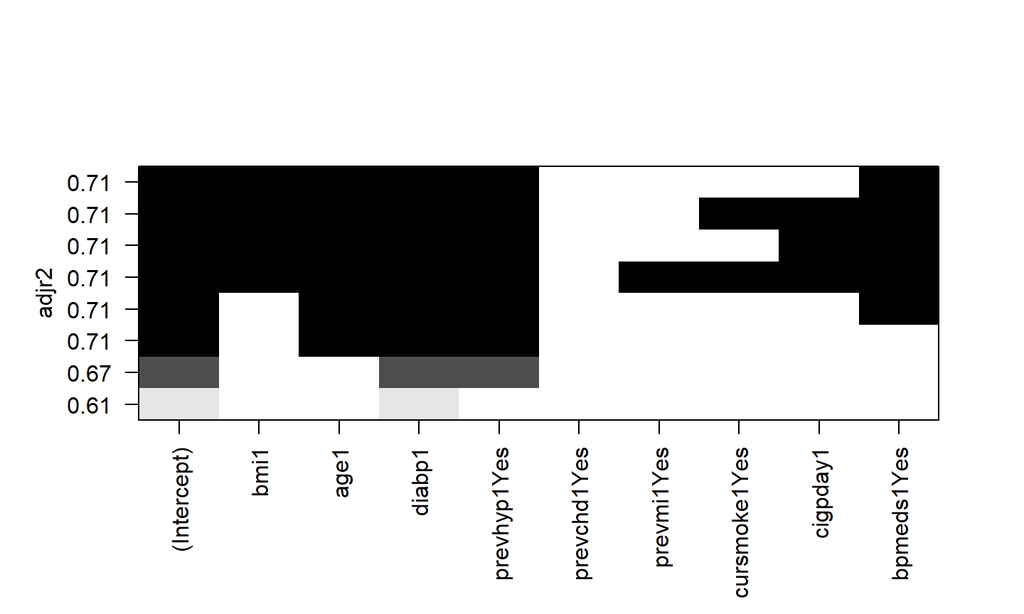

## Stepwise Regression

- Another concept for model selection can be is stepwise methods.
- The most used stepwise methods would either be a **forward selection** or **backwards elimination**.

## Forward Selection Procedure

- **Forward selection** starts with no variables in the mode.
- It then runs all possible regressions univariately.
- It chooses the value with the lowest p-value.
- Once a variable is in the model it then checks all regressions with 2 variables and adds the one with the lowest p-value.
- It will continue to do this until everything is in the model or adding another variable will make the model worse.

## Forward Selection Example

- Before we try this method we will do some data cleaning.
- Our first goal will be to create a dataset where all of the variables in our model have no missing data.
- This is called complete case analysis.

## Complete Case Preparation

```r
#Variables we care about in model
myvars <- c("sysbp1t", "bmi1", "age1", "diabp1", "prevhyp1", "prevchd1",
"prevmi1", "cursmoke1", "cigpday1", "bpmeds1")

#Selecting only these variables
fhs_sub_sel <- fhs[myvars]

#Selecting only those rows with complete cases
fhs_sub_sel <- fhs_sub_sel[complete.cases(fhs_sub_sel),]
```

## Running Forwards Stepwise

Now we are ready to run forwards selection either using AIC or BIC

```r
###################
##     RUN THIS IN R FOR CLASS    ##
###################

library(MASS)
#Begin with model of only intercept
int_mod <- lm(sysbp1t~ 1, data=fhs_sub_sel)

#Fit forward with AIC
step_aic <- stepAIC(int_mod, scope= ~ bmi1 + age1 + diabp1 + prevhyp1 + prevchd1 + prevmi1 +  cursmoke1 +
          cigpday1 + bpmeds1,  direction="forward", k=2)
step_aic$anova

#Define penalty for BIC
n = dim(fhs_sub_sel)[1]

#Fit forward with BIC
step_bic <- stepAIC(int_mod, scope= ~ bmi1 + age1 + diabp1 +
prevhyp1 + prevchd1 + prevmi1 +  cursmoke1 +
  cigpday1 + bpmeds1,  direction="forward", k=log(n))
step_bic$anova
```

## Backwards Stepwise

- **Backwards elimination** starts with everything in the model.
- It then removes the variable with the largest p-value.
- It runs the model again and looks for the next variable with the largest p-value.
- It will continue until either there are no variables in the model or removing a variable will make the model worse.

## Running Backwards Regression

```r
###################
##     RUN THIS IN R FOR CLASS    ##
###################

library(MASS)
# Start with everything in the model
full_mod <- lm(sysbp1t~ bmi1 + age1 + diabp1 + prevhyp1 + prevchd1 +
prevmi1 + cursmoke1 + cigpday1 + bpmeds1, data=fhs_sub_sel)


#Fit backward with AIC
step_aic <- stepAIC(full_mod,   direction="backward", k=2)
step_aic$anova

#Define penalty for BIC
n = dim(fhs_sub_sel)[1]

#Fit bacward with BIC
step_bic <- stepAIC(full_mod,   direction="backward", k=log(n))
step_bic$anova
```

## Comparing different Models

- Sometimes we wish to directly compare models.
- For example when we have a categorical variable, many times we want to treat this as a continuous variable and others we want to declare a reference group and let each group have it's own slope.

## Example: The PBC-3 trial in liver cirrhosis

- The PBC-3 trial was a randomized clinical trial conducted in six European hospitals.
- Between 1983 and 1987, 349 patients with liver disease, primary biliary cirrhosis (PBC), were randomized to a treatment or a placebo.
- The purpose of the trial was to study the effect of the treatment on Survival time.

## PBC Data

- We have considered the `pbc` data before.
- We considered platelet counts and we have a categorical variable of histological disease stage.
- We may be interested in seeing if we can treat this as linear or by categories.

## Read in PBC Data

```r
pbc <- read.table("pbc.csv", header=TRUE, sep=",")
colnames(pbc) <- c("casenum", "n.days", "death", "treated", "age" , "sex",
"ascites", "hepatomegaly", "spiders", "edema",
"bilirubin", "choles", "albumin", "ur.cop",
"alk.phos", "sgot", "trigly",
"plat.cnt", "pt", "dis.stage")
```

## Fit Histologic Disease Stage As Linear

```r
fit.pbc1 <- lm(plat.cnt ~ dis.stage, data=pbc)
kable(tidy(fit.pbc1, conf.int=T)[, -c(3,4)])
```

## Fit Histologic Disease Stage As Linear

| term | estimate | p.value | conf.low | conf.high |
| --- | --- | --- | --- | --- |
| (Intercept) | 345.2 | 0 | 307.5 | 383.0 |
| dis.stage | -27.4 | 0 | -39.3 | -15.5 |

## Conclusions

- In this model we viewed the change in disease stages to be linear and that it was the same change from group 1 to 2 as from 2 to 3.
- However we may have wanted to let each group have their own slope and compare these models.

## Fit Histologic Disease Stage As Categorical

```r
fit.pbc2 <- lm(plat.cnt ~ as.factor(dis.stage), data=pbc)
kable(tidy(fit.pbc2, conf.int=T)[, -c(3,4)])
```

## Fit Histologic Disease Stage As Categorical

| term | estimate | p.value | conf.low | conf.high |
| --- | --- | --- | --- | --- |
| (Intercept) | 278.47 | 0.000 | 231.5 | 325.388 |
| as.factor(dis.stage)2 | 18.76 | 0.478 | -33.2 | 70.741 |
| as.factor(dis.stage)3 | -7.91 | 0.755 | -57.7 | 41.907 |
| as.factor(dis.stage)4 | -49.51 | 0.052 | -99.6 | 0.533 |

## \(F\)-Test for Model Comparison

- Then we could use the \(F\)-test to compare both of these models and determine which one is better to use.
- The \(F\)-test considers two models \(M_1\) and \(M_2\). \(M_1\) has \(p_1\) covariates and a residual sum of squares, \(RSS_1\).
- \(M_2\) has \(p_2>p_1\) and a residual sum of squares, \(RSS_2\).
- We also have that \(M_1\) is nested inside of \(M_2\).

## \(F\)-Test for Model Comparison

- Then we have \[F= \dfrac{\dfrac{RSS_1-RSS_2}{p_2-p_1}}{\dfrac{RSS_2}{N-p_2-1}}\]
- Under the assumptions that the residuals of both models are normally distributed we have that \(F\) follows an \(F\) distribution with \(p_2-p_1\) and \(N-p_2-1\) degrees of freedom.

## Conclusion

- In our example we have that the model with disease stage coded with dummy variables is the larger model and when we consider a linear trend across the stages we have this model nested inside the larger model.
- We can perform this \(F\)-test in R.

## \(F\)-Test in R

```r
anova(fit.pbc1, fit.pbc2)
```

## \(F\)-Test in R

```
## Analysis of Variance Table
##
## Model 1: plat.cnt ~ dis.stage
## Model 2: plat.cnt ~ as.factor(dis.stage)
##   Res.Df     RSS Df Sum of Sq    F Pr(>F)
## 1    306 2630489
## 2    304 2592651  2     37838 2.22   0.11
```